# Decision Making with Sentiment Analysis in R

From Social Media Noise to Managerial Action

Mustafa Asım Ruhi 401190044  
ruhi.mustafa@stud.hs-fresenius.de

Fresenius University of Applied Sciences  
Course: Data Analysis for Decision-Making  
Professor: Prof. Dr. Stephan Huber  
2 June 2026

## Research Question

How can customer tweets be transformed into decision-relevant insights for airline management?

## What is Sentiment Analysis?

Sentiment analysis is a text mining method used to identify opinions, emotions, and attitudes in written language.

Positive

Neutral

Negative

## Why It Matters for Decision-Making

Companies receive large amounts of customer feedback.

Managers need fast and structured insights.

Sentiment analysis helps prioritize business actions.

## Different Sentiment Analysis Methods

| Method | Basic idea | Why not used / selected? |
| --- | --- | --- |
| Lexicon-based | Uses predefined sentiment dictionaries | Selected because it is transparent and easy to reproduce in RStudio |
| Machine learning | Trains a model on labeled text data | Requires training/testing setup |
| Transformer-based | Uses context-aware models such as BERT | More complex for a short live demo |
| Hybrid | Combines dictionaries and machine learning | More advanced setup |

In this project, I use a lexicon-based approach because it is transparent, reproducible, and suitable for a short RStudio demonstration.

## From Text to Managerial Action

1Collect text

2Clean data

3Measure sentiment

4Find problems

5Recommend action

## Case Study: Airline Tweets

The example uses **14,640 airline-related tweets** classified as negative, neutral, or positive.

| Sentiment | Tweets | Share |
| --- | --- | --- |
| negative | 9178 | 62.7% |
| neutral | 3099 | 21.2% |
| positive | 2363 | 16.1% |

## Sentiment by Airline

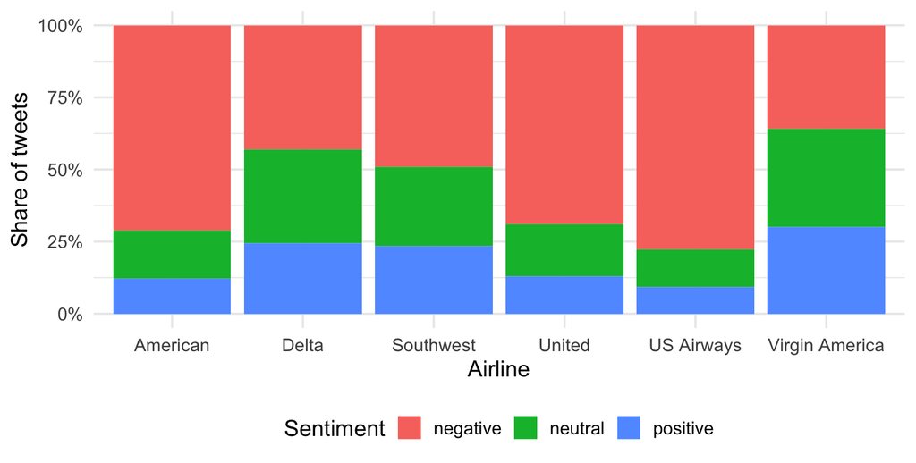

## Main Negative Reasons

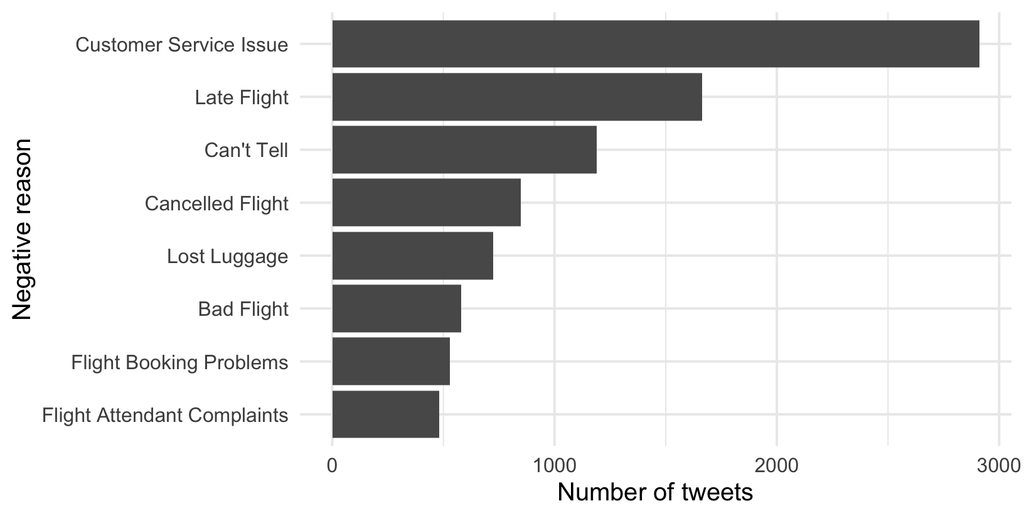

## R Workflow: Tokenization

```r
tweets_words <- tweets |>
  mutate(tweet_id = row_number()) |>
  select(tweet_id, airline, airline_sentiment, text) |>
  unnest_tokens(word, text) |>
  anti_join(stop_words, by = "word")
```

**Example**  
The flight was delayed and the service was terrible.  
**After tokenization:**  
flight delayed service terrible

## Lexicon Choices

| Lexicon | Output | Usefulness |
| --- | --- | --- |
| **Bing** | Positive / negative | Simple and transparent for live demo |
| **AFINN** | Numerical score | Shows sentiment intensity |
| **NRC** | Emotion categories | Shows anger, fear, joy, sadness, and trust |

**Why Bing?** Bing is easy to explain, reproducible in RStudio, and clearly shows which words are matched as positive or negative.

## Lexicon-Based Sentiment Analysis

```r
word_sentiments <- tweets_words |>
  inner_join(get_sentiments("bing"), by = "word")
```

**Example word matching with Bing lexicon**  
The flight was delayed and terrible, but the staff was helpful and comfortable.  
terrible → negative delayed → negative helpful → positive comfortable → positive  
Words that are not found in the dictionary are not labelled as neutral; they are excluded from the lexicon-based count.

## Frequent Sentiment Words

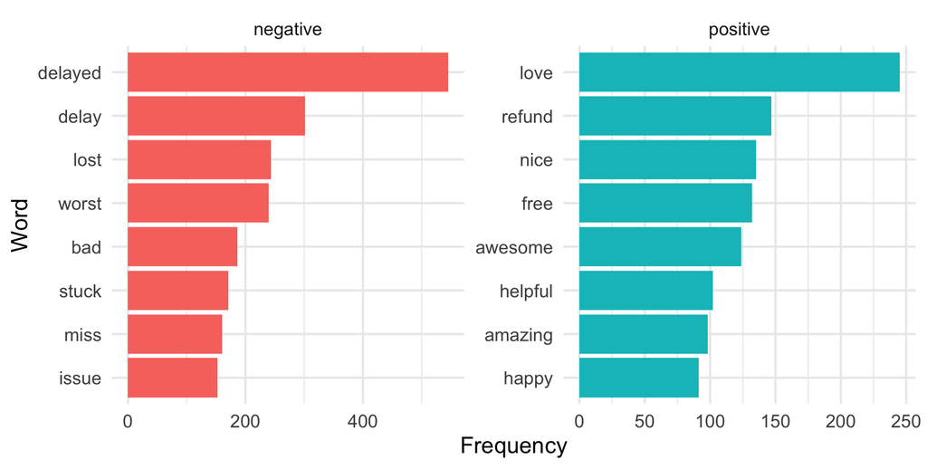

## From Analysis to Decisions

| Problem | Tweets | Managerial action |
| --- | --- | --- |
| Customer Service Issue | 2910 | Improve support capacity and service recovery. |
| Late Flight | 1665 | Improve delay communication and punctuality. |
| Can’t Tell | 1190 | Investigate this category further. |
| Cancelled Flight | 847 | Strengthen rebooking and compensation. |
| Lost Luggage | 724 | Improve baggage tracking. |

## Managerial Interpretation

The real value is not only knowing whether customers are happy or unhappy.

The real value is knowing which operational problem should be solved first.

## Strengths and Limitations

**Strengths**  
Fast analysis  
Reproducible workflow  
Useful for monitoring

**Limitations**  
Sarcasm is difficult  
Context can be missed  
Human interpretation is needed

## In-Class Exercise

Students analyze three short customer comments in R and recommend one managerial action.

```r
customer_comments <- tibble(
  text = c(
    "The flight was delayed and the service was terrible",
    "The staff was helpful and the flight was comfortable",
    "My luggage was lost and nobody helped me"
  )
)

customer_comments |>
  unnest_tokens(word, text) |>
  anti_join(stop_words, by = "word") |>
  inner_join(get_sentiments("bing"), by = "word") |>
  count(sentiment)

# Show which words were matched as positive or negative
customer_comments |>
  unnest_tokens(word, text) |>
  anti_join(stop_words, by = "word") |>
  inner_join(get_sentiments("bing"), by = "word") |>
  select(word, sentiment) |>
  arrange(sentiment, word)
```

## Exercise Question

**Question:**  
Which managerial action would be most suitable based on the negative words in the comments?  
**A)** Reduce the number of customer support channels  
**B)** Improve delay communication and luggage recovery processes  
**C)** Ignore negative comments because they are unstructured data  
**D)** Only focus on positive words

## Conclusion

Sentiment analysis turns unstructured customer feedback into practical decision support.

For managers, the key question is not only: **“What is the sentiment?”**  
It is: **“What decision should this sentiment trigger?”**

## References

Huber, S. (2025). *How to use R for data science*. https://hubchev.github.io/ds/

Liu, B. (2012). *Sentiment analysis and opinion mining*. Morgan & Claypool Publishers. https://www.cs.uic.edu/~liub/FBS/SentimentAnalysis-and-OpinionMining.pdf

Pang, B., & Lee, L. (2008). Opinion mining and sentiment analysis. *Foundations and Trends in Information Retrieval, 2*(1–2), 1–135. https://doi.org/10.1561/1500000011

Silge, J., & Robinson, D. (2017). *Text mining with R: A tidy approach*. O’Reilly Media. https://www.tidytextmining.com/

Wickham, H., Cetinkaya-Rundel, M., & Grolemund, G. (2023). *R for data science: Import, tidy, transform, visualize, and model data* (2nd ed.). O’Reilly Media. https://r4ds.hadley.nz/

*Twitter US Airline Sentiment dataset*. Airline-related tweets used for sentiment and negative reason analysis. https://raw.githubusercontent.com/ruchitgandhi/Twitter-Airline-Sentiment-Analysis/master/Tweets.csv

## Thank You

**Mustafa Asım Ruhi**  
Student number: 401190044  
Data Analysis for Decision-Making  
2 June 2026